# Hostel Ratings And Prices

12/10/2019

## Introducing the Data

- We obtained our sample of 342 Japanese hostels from [kaggle user Koki Ando](https://www.kaggle.com/koki25ando/hostel-world-dataset/version/3)
- In the first section of project we will use descriptive statistics to describe our sample
- For Parts 2-5, we will be conducting statistical inference on the population of Japanese Hostels on Hostelworld.com
- Our sample includes 12 variables, however, these were our variables of interest:
  - Ratings: Summary Score, Ratings Band, and Specific Ratings based on experiencial qualities
  - City: Tokyo, Osaka, Kyoto, Hiroshima, Fukuoka-City
  - Lowest Price: lowest price for a one night stay
  - Value for money: User rating of whether their stay was worth the money

## Distribution of variables

Most hostels were well rated, and while low ratings exist, many seem to be outliers

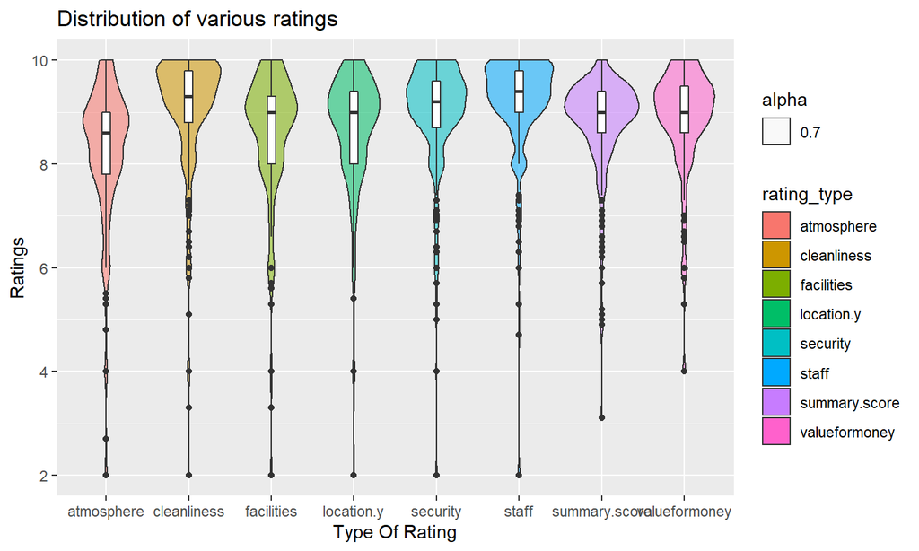

## Outliers

- We want to remove the most extreme outliers for our variables
- The standard way to do this is to look at things that lie outside this range:

\[median \pm 1.5*IQR_{data}\] - The variables in the data set were often skewed, especially ratings which were almost always high, so removing outliers was important for our analysis  
- However, one outlier for price was so absurd we investigated it further

- The stays that cost more than 1,000,000 YEN
- Through google searches, we found the hostels that cost over a million yen were because of data entry errors.

## Price Distribution

### After Removing the 1,000,000 Yen Outliers

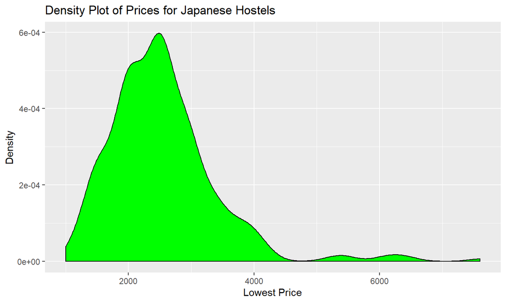

## Correlation Table

|  | Lowest Price | Summary Score | Atmosphere | Cleanliness | Value for Price | Staff | Facilities | Security | Distance |
| --- | --- | --- | --- | --- | --- | --- | --- | --- | --- |
| Lowest Price | 1 | -0.05 | -0.13 | 0 | -0.14 | -0.04 | 0.06 | -0.03 | -0.02 |
| Summary Score | -0.05 | 1 | 0.84 | 0.84 | 0.87 | 0.83 | 0.9 | 0.79 | -0.02 |
| Atmosphere | -0.13 | 0.84 | 1 | 0.64 | 0.73 | 0.68 | 0.7 | 0.54 | 0.02 |
| Cleanliness | 0 | 0.84 | 0.64 | 1 | 0.69 | 0.63 | 0.8 | 0.59 | -0.04 |
| Value for Price | -0.14 | 0.87 | 0.73 | 0.69 | 1 | 0.63 | 0.75 | 0.68 | 0.03 |
| Staff | -0.04 | 0.83 | 0.68 | 0.63 | 0.63 | 1 | 0.69 | 0.69 | 0.06 |
| Facilities | 0.06 | 0.9 | 0.7 | 0.8 | 0.75 | 0.69 | 1 | 0.64 | -0.01 |
| Security | -0.03 | 0.79 | 0.54 | 0.59 | 0.68 | 0.69 | 0.64 | 1 | 0.07 |
| Distance | -0.02 | -0.02 | 0.02 | -0.04 | 0.03 | 0.06 | -0.01 | 0.07 | 1 |

## Part 2: One Sample Statistical Inference

We are testing whether Hiroshima’s sample mean of summary scores differs significantly from the our population parameter of interest, i.e. the population mean of Hiroshima’s summary scores.

Our hypotheses are as follows:

\[ H_o: \mu_{_{H}} = 8.782569 \]

\[H_{a}: \mu_{_{H}} \neq 8.782569 \]

```
##
##  One Sample t-test
##
## data:  hiroshima$summary.score
## t = 5.1726, df = 13, p-value = 0.0001794
## alternative hypothesis: true mean is not equal to 8.782569
## 95 percent confidence interval:
##  9.009020 9.333837
## sample estimates:
## mean of x
##  9.171429
```

## Analysis of Test for Hiroshima’s Summary Scores

```
## [1] "Cohen's d:  0.4046792"
```

## Cities’ Confidence Intervals for Mean Summary Score

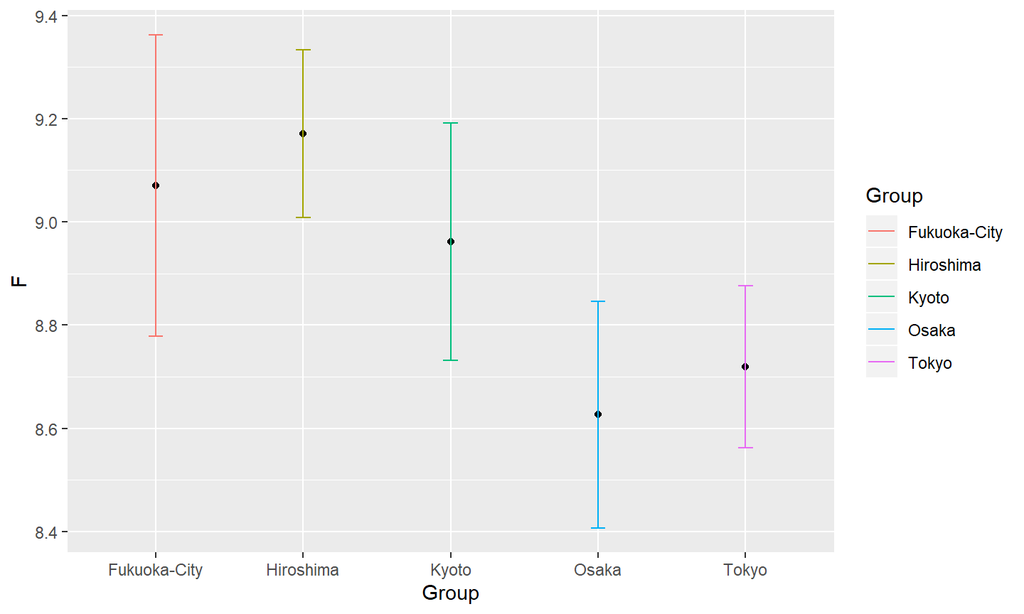

## Part 3: Proportion Test for Superb Hostel Ratings

For this test, our parameter of interest is the population proportion of superb rating bands for Japanese Hostels. We are testing whether the proportion of superb ratings in our sample differs significantly from population proportion.

Our hypotheses are as follows: \[ H_{0}: p_{superb} = 0.5 \] \[ H_{a}: p_{superb} \neq 0.5 \]

```
##
##  1-sample proportions test with continuity correction
##
## data:  182 out of 342, null probability 0.5
## X-squared = 1.2895, df = 1, p-value = 0.2561
## alternative hypothesis: true p is not equal to 0.5
## 95 percent confidence interval:
##  0.4777628 0.5858305
## sample estimates:
##         p
## 0.5321637
```

## Results of Hypothesis Test on Superb Ratings

- For our test, we found that we cannot say that the sample proportion of superbly rated hostels differs significantly from our population parameter of interest.
- Our sample estimate being within our confidence interval means that our confidence interval is in agreement with the results of our test.
- Even though our results were not statistically significant, we evaluated the effect size as well, and found that the results of this test were practically insignificant as well due to the tiny effect size.

```
## [1] "Effect Size:"
```

```
## [1] 8.555732e-08
```

## Confidence Interval for a Superb Hostel Rating

The interpretation of the confidence interval: We can say with 95% confidence that all Japanese hostels on the website will have 47.9% - 58.5% of their ratings will be “Superb”

```
## [1] "The 95% Confidence Interval is: 0.47928 to 0.58505"
```

## Part 4: Two Sample Statistical Inference

- For our two sample test, we considered the variable distance from city center.
- Then we created considered whether certain attributes of the sample of hostels that are far from the city center is significantly different from those that are close to the city center.
- Our first test is for the mean price, and our hypotheses are as follows: \[H_{0}: \mu_{far} - \mu_{close} = 0 \] \[H_{a}: \mu_{far} - \mu_{close} \neq 0 \]

## Test for Difference in Price

We fail to reject the null hypothesis, with the confidence interval in agreement with our p-value. Our effect size is also practically insignificant.

```
##
##  Welch Two Sample t-test
##
## data:  high.dist$price.from and low.dist$price.from
## t = 1.3952, df = 165.03, p-value = 0.1648
## alternative hypothesis: true difference in means is not equal to 0
## 95 percent confidence interval:
##  -4923.563 28643.801
## sample estimates:
## mean of x mean of y
## 14500.000  2639.881
```

```
##
## Cohen's d
##
## d estimate: 0.1536099 (negligible)
## 95 percent confidence interval:
##       lower       upper
## -0.06198492  0.36920463
```

## Test for Difference in Score

Due to our p-value and our confidence interval not including 0, we reject our null hypothesis. While our effect size is small, it is not negligible.

```
##
##  Welch Two Sample t-test
##
## data:  high.dist$summary.score and low.dist$summary.score
## t = -2.2501, df = 314.34, p-value = 0.02513
## alternative hypothesis: true difference in means is not equal to 0
## 95 percent confidence interval:
##  -0.4557195 -0.0305305
## sample estimates:
## mean of x mean of y
##  8.656875  8.900000
```

```
##
## Cohen's d
##
## d estimate: -0.2518858 (small)
## 95 percent confidence interval:
##       lower       upper
## -0.47307376 -0.03069783
```

## Test for Difference in Value for Money

Our p-value is insignificant and our confidence interval is in agreement. Our effect size is also negligible, so we fail to reject the null hypothesis.

```
##
##  Welch Two Sample t-test
##
## data:  high.dist$valueformoney and low.dist$valueformoney
## t = -1.3958, df = 301.78, p-value = 0.1638
## alternative hypothesis: true difference in means is not equal to 0
## 95 percent confidence interval:
##  -0.39807391  0.06769655
## sample estimates:
## mean of x mean of y
##  8.765000  8.930189
```

```
##
## Cohen's d
##
## d estimate: -0.15619 (negligible)
## 95 percent confidence interval:
##       lower       upper
## -0.37684176  0.06446167
```

## Part 5: Probability of a Stay being ‘Worth the Money’

- For this part of our project our goal was to approach the probability of website users finding their stay was worth the money.
- Our first look into this was to create a probability tree of the intersections of the probabilities of a hostel being close or far from a city center, and a user rating of the hostel being worth the money and not worth the money.
  - Both of these variables were recoded to be used in binary terms.
- Our second look was to calculate the conditional probabilities of users finding that their stay was worth the money, given that they were close or far from a city center.

## Probability Tree

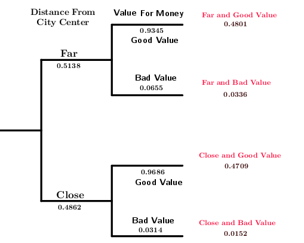

## Conditional Probabilities

- P(High Value|Low Distance) = 0.9685535
- P(Low Value|Low Distance) = 0.03144654
- P(High Value|High Distance) = 0.9345238
- P(Low Value|High Distance) = 0.06547619
- With these values we could derive Bayes’ Law like so:

\[P(Value|Distance)= {P(Distance|Value) \times P(Value)\over{P(Distance)}} \]

## Results of Probability Analysis

- Because users rarely rate hostel visits poorly, it is hard to see the impact distance has on the probability of finding a stay to be worth the price.
- However, in the conditional probabilities, we see a slight difference in probability of a user rating the hostel low given that the distance was far from the city center (albeit the difference is quite small).
- Results would be clearer if we conducted the same analysis for individual cities. If we conducted this individual analysis, each city would bring a different meaning to distance (i.e. far or close) to the city center; thus, the impact of distance on value may be different.

## Conclusions

### What Affects Ratings?

- Low price does not affect ratings.
- We see that overall atmosphere, facilities, and cleanliness correlate with a positive summary score.
- We also find that distance is not a factor in a postive value evaluation of the stay.
- In a future study, it would be interesting to view countries nearby, run a two-sample t-test, and compare results of Japanese hostels and other country’s hostels on what factors impact their ratings.